# Faza 2

Tomasz Wąs, Wojciech Szymański

15 stycznia 2017

# Wstępna selekcja danych (1. faza)

Zanim przystąpiliśmy do badania strategii rozwiązywania testów, przeprowadziliśmy wstępną selekcję danych (w pierwszej fazie).

- Czas zamieniliśmy na sekundy
- Usunęliśmy rekordy z pozycją równą -1
- A także z czasem większym od 15 minut i mniejszym niż 0.5 sekundy

# Wybór próbki uczniów

Aby móc porównywać ze sobą strategie rozwiązywania testów poszczególnych uczniów, należy rozpatrywać tych, którzy stanęli przed podobnym zadaniem. Zatem wybraliśmy tych, którzy:

- Rozwiązywali test zarówno z Czytania jak i Matematyki
- Najpierw mieli zadania z Czytania, potem z Matematyki
- Obie te części były przed częściami 3 i 4 (z przyrody)

# Kolejna selekcja danych

Dodatkowo usunęliśmy dane o uczniach, którzy rozwiązali mniej niż 5 zadań w którejś z części.

Także tych, o średnim czasie rozwiązywania zadań w którejkolwiek części przekraczającym 5 minut.

```r
d<-d[-which(d$R_count<5),]
d<-d[-which(d$M_count<5),]
d<-d[-which(d$M_mean>300),]
d<-d[-which(d$R_mean>300),]
d<-d[d$p1_mean==d$R_mean, ]
```

# Przekrój danych po selekcji (mapa)

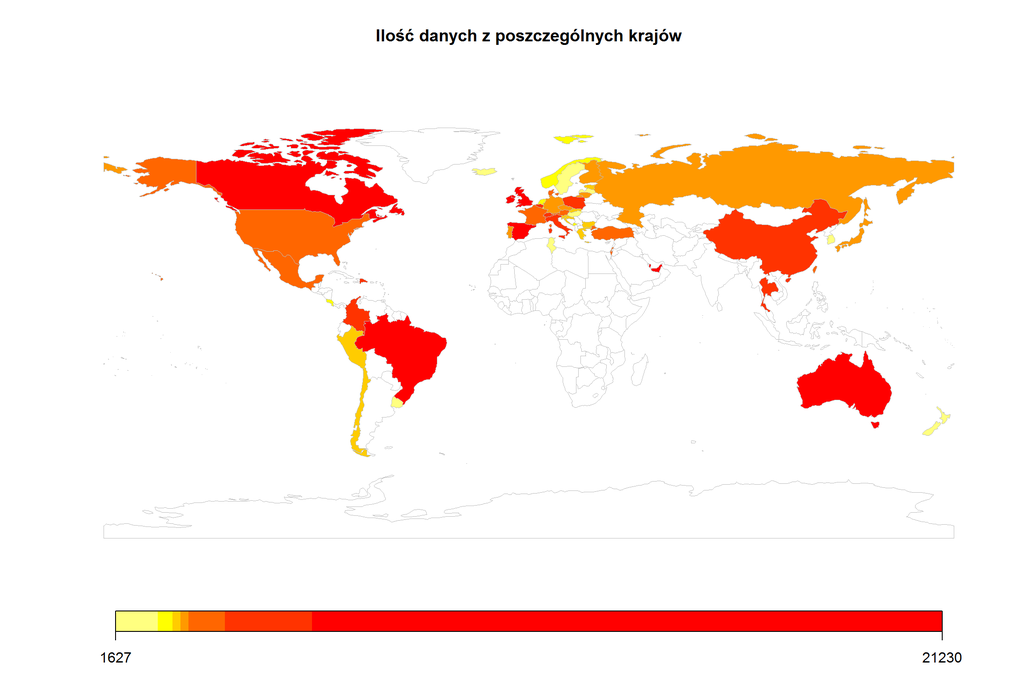

# Liczebność danych w wybranych krajach

```
##    Pozycja                 Kraj No.Obs. No.Obs.Org.
## 1        1 Massachusettes (USA)     828       30071
## 2        2 North Carolina (USA)     840       34801
## 3       10              Tunisia    2589      102071
## 4       20              Croatia    2977      110451
## 5       30                Japan    3216      114796
## 6       40               France    3574      119189
## 7       44               Poland    4365      130145
## 8       50          Switzerland    6190      218431
## 9       57                Qatar   12167      380634
## 10      58      Spain (Regions)   17624      608734
```

# Przekrój danych po selekcji (średnie w krajach)

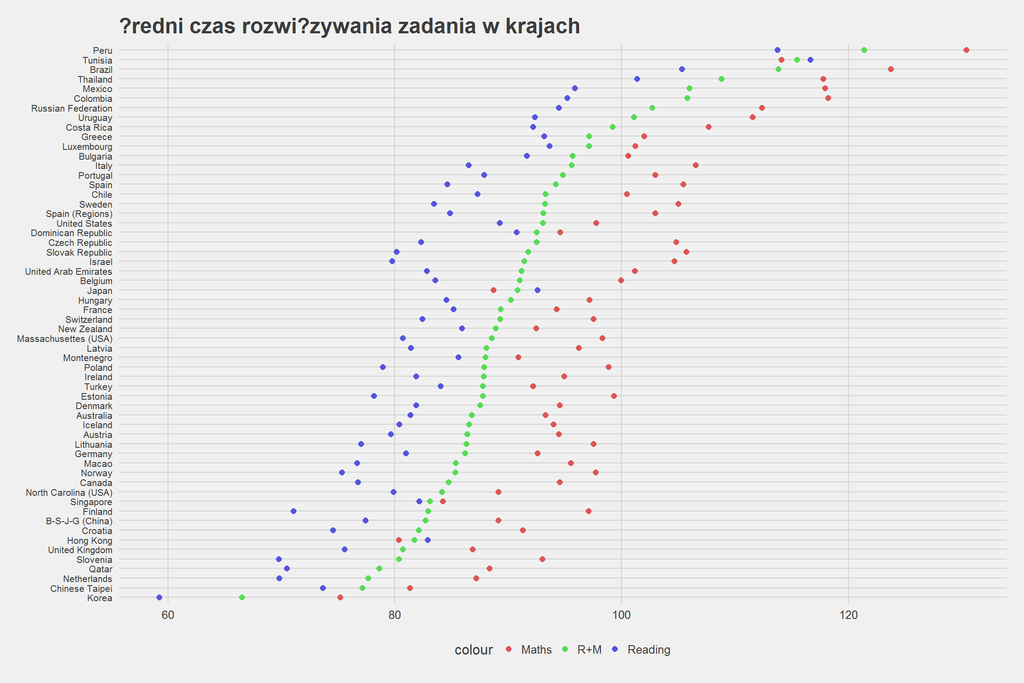

# Przekrój danych po selekcji (kwantyle w krajach)

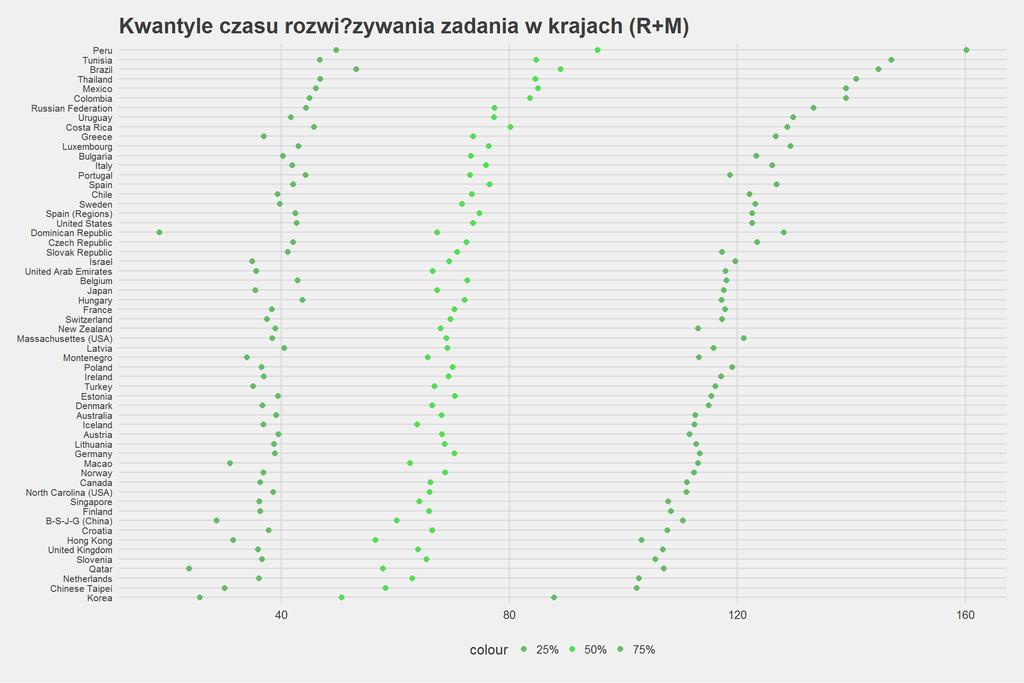

# Przestrzeń metryczna uczniów

Określiliśmy czterowymiarową przestrzeń, w której dwa wymiary to średni czas rozwiązywania zadań z danego obszaru, a pozostałe dwa to ich odchylenia standardowe.

Każdy uczeń jest zatem punktem w tej przestrzeni, a odległość dwóch uczniów od siebie określamy za pomocą metryki miejskiej.

$$d(uczeń_x,uczeń_y)=\Sigma_{i=1}^4(|x_i-y_i|)$$

$$=|\mu_{R,x}-\mu_{R,y}|+|\sigma_{R,x}-\sigma_{R,y}|+|\mu_{M,x}-\mu_{M,y}|+|\sigma_{M,x}-\sigma_{M,y}|$$

# Wstępne podsumowanie danych o uczniach

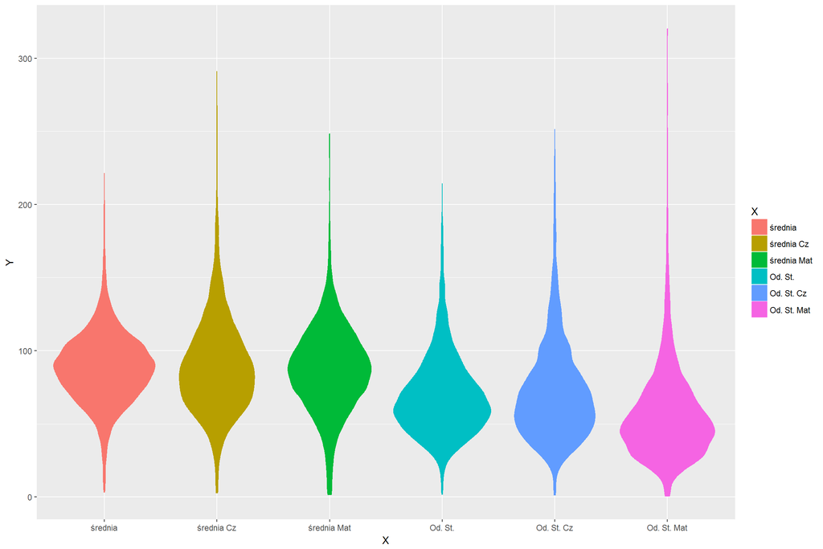

# Zastosowane Metody

Aby podzielić uczniów na grupy według ich strategii rozwiązywania testów zastosowaliśmy cztery metody:

-Single

-Average

-Ward

-Complete

# Metoda Single (Dendrogram)

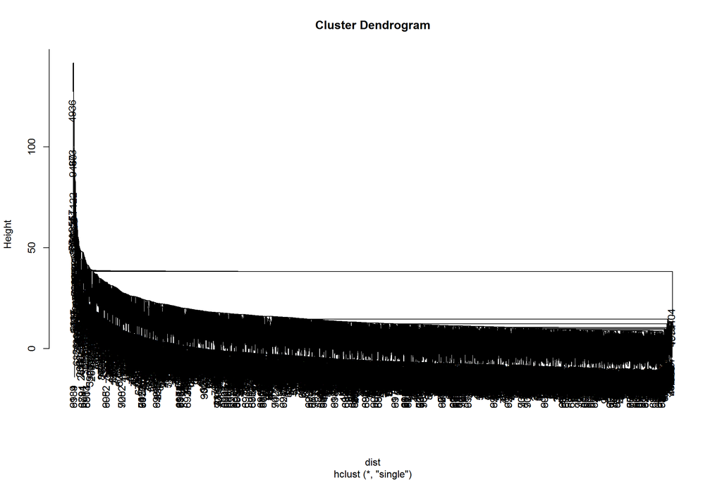

# Metoda Average (Dendrogram)

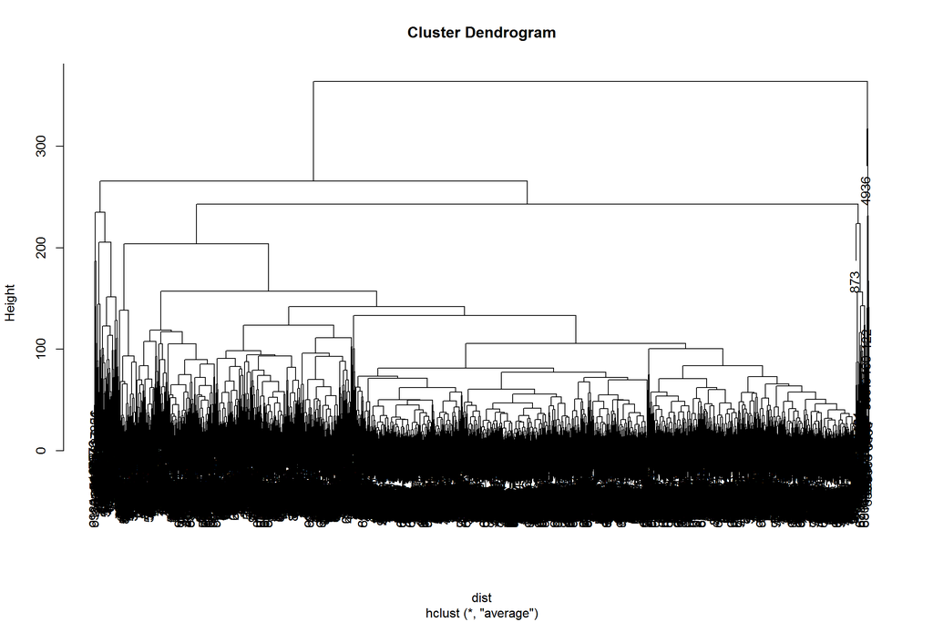

# Metoda Ward (Dendrogram)

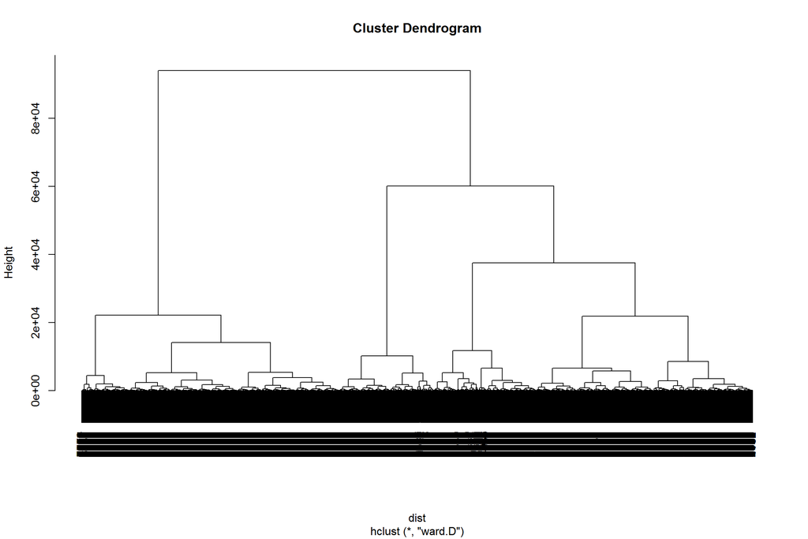

# Metoda Ward (3 Kategorie)

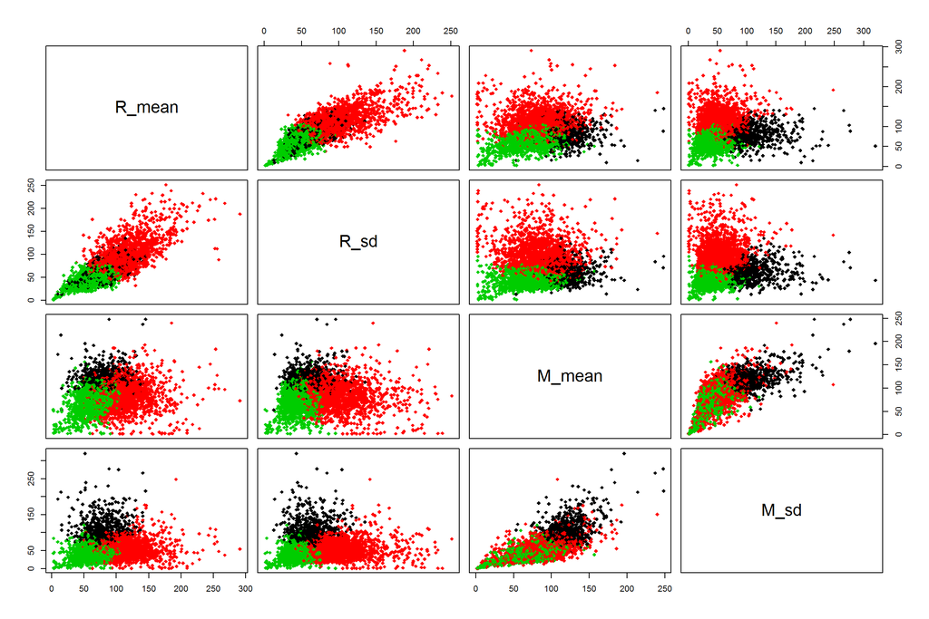

# Metoda Complete (Dendrogram)

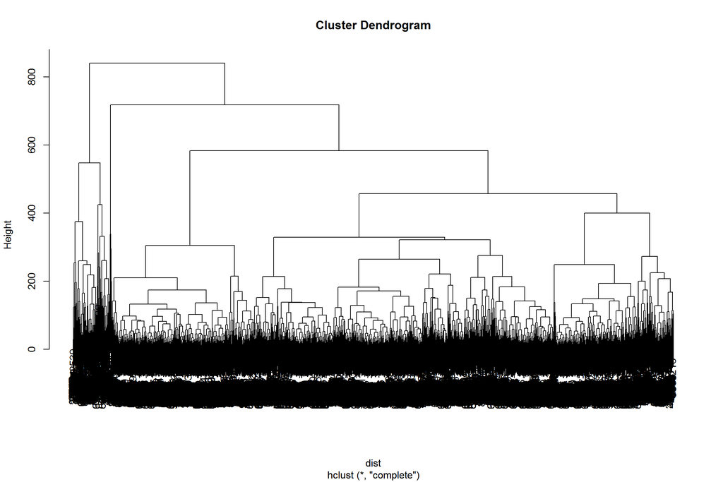

# Metoda Complete (6 Kategorii)

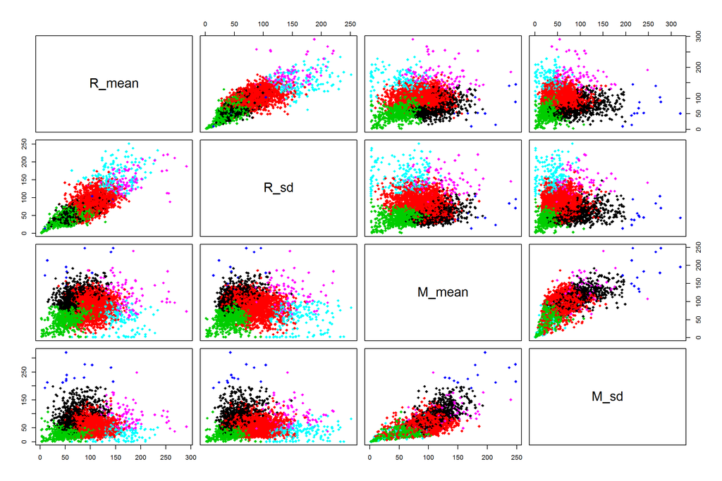

# Podsumowanie Kategorii

| No. | Kategoria | Średnia | Średnia (Cz) | Średnia (M) | Od.Std. | Od.Std. (Cz) | Od.Std. (M) | Liczba |
| --- | --- | --- | --- | --- | --- | --- | --- | --- |
| 1 | Czarna | 85.441 | 68.661 | 105.819 | 71.457 | 53.416 | 83.185 | 918 |
| 2 | Czerwona | 96.353 | 100.165 | 91.512 | 73.430 | 81.185 | 56.698 | 2291 |
| 3 | Zielona | 63.479 | 65.530 | 61.097 | 42.119 | 46.424 | 32.592 | 1091 |
| 4 | Niebieska | 117.880 | 70.143 | 184.827 | 165.161 | 54.584 | 239.686 | 13 |
| 5 | Błekitna | 110.562 | 150.354 | 59.467 | 128.830 | 157.127 | 37.055 | 183 |
| 6 | Różowy | 149.885 | 173.161 | 118.656 | 129.741 | 143.910 | 90.758 | 99 |